# SEGURIDAD EN EL CICLO DE DESARROLLO

### Implementación de seguridad en el modelo de desarrollo ágil XP

Leidy Johana Pulido Rodríguez Cod: 1911023821  
Jorge Luis Álvarez Medina Cod: 1911023817  
José Ricardo Suarez Chacón Cod: 1821026063  
Robinson Daniel Clemente Córdoba Cod: 100231240  
Carlos Andrés Minota Córdoba Cod: 100261147

Presentado a: Blanco Ignacio

SEGURIDAD EN EL CICLO DE DESARROLLO-[GRUPO B01]

Facultad de Ingeniería, Diseño e Innovación.  
Ingeniería de Software.  
Politécnico Gran Colombiano – diciembre de 2022.

## **Objetivo**

Extreme programing es una metodología de desarrollo de software que pertenece a las metodologías ágiles, además de valores y principios, ofrece buenas prácticas de planificación, organización, comunicación e ingeniería de software que, combinadas con valores y principios, crean una excelente cultura de equipo.

Es una de las metodologías más reconocidas porque ha demostrado ser muy exitoso en muchas organizaciones de diferentes tamaños e industrias internacionales, su reconocimiento se debe a que enfatiza la satisfacción del cliente, donde los gerentes, los consumidores y los desarrolladores son aliados por igual en cooperación y en equipo.

## **Conceptos básicos de seguridad**

- **Seguridad de la información:** incorporación de medidas y técnicas para controlar y proteger toda la información procesada en una organización y para asegurar que la información no sale del sistema establecido por la organización. Para las empresas es parte central de sus actividades, debido a que los datos que maneja son indispensables para las actividades que desarrollan.
- **Confidencialidad:** Todas las personas físicas o jurídicas involucradas en el manejo de datos personales no públicos deben garantizar siempre la confidencialidad de los datos incluso después de que haya terminado su relación con una tarea no pública. incluye la gestión de datos capaz de transmitir o transferir datos solo si corresponde al desarrollo de la actividad autorizada.
- **Integridad:** Los sistemas de gestión de la información deben asegurar su integridad, es decir, la presentación de la información tal y como se pretende, sin cambios o manipulaciones que no estén expresamente permitidas. El objetivo principal es garantizar la transmisión de datos en un entorno seguro utilizando protocolos y técnicas seguras para evitar riesgos potenciales. Esto es para garantizar que la información sea precisa y completa, lo que significa que no se modifica sin permiso.
- **Disponibilidad:** Tiene como objetivo garantizar que la información esté disponible cuando se necesite, garantizando que esta sea accesible y utilizable por demanda cuando así sea requerido. En este sentido, se asegura que la información esté permanentemente disponible para todas las personas o entidades autorizadas para inspeccionarla y conocerla. Para ello, deben existir medidas de soporte y seguridad para acceder a los datos en caso de ser necesario y evitar interrupciones en el servicio
- **Autenticación:** consiste en asegurarse de que alguien o algo es quien dice ser. Por lo general, las aplicaciones se autentican usando un nombre de usuario y una contraseña, pero hay otras formas de hacerlo usando tres "factores de autenticación"
- **Autorización:** otorgar a los usuarios los derechos de acceso necesarios después de la autenticación. En otras palabras, la autenticación consiste en perfiles de usuario que deben construirse según la regla o principio de privilegio mínimo, es decir. reciben los derechos que son esenciales para el desarrollo de sus tareas.
- **No Repudio:** Esto significa que el usuario de la aplicación no puede negar (o denegar) la ejecución de la acción. En otras palabras, es la capacidad de demostrar que el usuario definitivamente completó algo en la aplicación, por lo que es una información clave durante una investigación.
- **Información Sensible:** Para las empresas es una parte importante de sus operaciones, porque la información que procesa es vital para sus operaciones. En la mayoría de los casos, los sistemas organizativos se basan en las nuevas tecnologías, por lo que la seguridad no puede confundirse con la seguridad de los datos y la información, que están íntimamente relacionadas.
- **Suplantación de identidad:** Es una actividad maliciosa donde el atacante se hace pasar por otra persona para cometer algún tipo de fraude, bullying (ciberbullying). Los ejemplos incluyen crear el perfil de la red social de otra persona y comunicarse con otros usuarios haciéndose pasar por ellos.
- **Pirata informático:** Es aquella cuya práctica habitual es reproducir, recuperar y distribuir contenidos (software, vídeos, música, etc.) de forma lucrativa ya gran escala, para lo cual no cuenta con licencia o permiso de su creador. Usualmente utiliza una computadora o soporte técnico para estas actividades. Una de las formas más conocidas de piratería de contenido es la piratería de software.
- **Hacker:** Es alguien que encuentra debilidades en una computadora o en un sistema de comunicación e información. Los piratas informáticos pueden estar motivados por una serie de razones, incluidas las ganancias.
- **Phishing:** Se trata de una estafa telemática, con la que el estafador intenta obtener información confidencial (contraseñas, datos bancarios, etc.) de usuarios legítimos. Un estafador o cazador se hace pasar por una persona o empresa de confianza para que el destinatario de una comunicación electrónica aparentemente oficial (correo electrónico, fax, mensaje de texto o teléfono) crea que es genuina y así facilite la adquisición de información privada de su interés.
- **Keylogger:** Es un software o hardware que puede capturar y almacenar pulsaciones de teclas en el teclado de una computadora integrada. Se encuentra entre el teclado y el sistema operativo para realizar su tarea. Si se usa ilegalmente, se convierte en una herramienta porque puede usarse para recopilar información confidencial, como contraseñas o información financiera, que luego se envía a terceros para su uso delictivo.
- **Cortafuegos:** Cuando navegamos por Internet y usamos un sitio web, este se comunica con nuestro equipo para crear una conexión entre ambos. Los cortafuegos o cortafuegos analizan estas conexiones para bloquear aquellas que puedan suponer una amenaza para nosotros.
- **Malware:** es un tipo de software diseñado para dañar o penetrar en un sistema de información sin el permiso de su propietario. Una palabra que proviene de la asociación de términos ingleses para malware.
- **Scumware:** Un tipo de malware que evita a toda costa desinstalar o desinstalar porque tiene protección contra habilitarlo, convirtiéndolo en un programa molesto y no deseado.
- **Browser hijacker:** Se llama así o secuestro del navegador a la apropiación que realizan algunos spyware sobre el buscador, lanzando popups, modificando la página de inicio o de búsqueda predeterminada, etcétera.
- **Firewall perimetral de red:** Una de las herramientas de seguridad más importantes es un firewall. Está diseñado para escanear paquetes de red y bloquearlos o no según reglas predefinidas por el administrador del sistema.
- **Spoofing:** Es una técnica de robo de identidad en Internet por parte de un ciberdelincuente, generalmente a través del proceso de investigación o el uso de malware. Los ataques a la seguridad de las redes mediante técnicas de suplantación de identidad amenazan la privacidad de los usuarios y la integridad de sus datos.
- **Denegación de servicio (DDos):** Es un conjunto de técnicas diseñadas para apagar un servidor. El objetivo de este tipo de ataque es sobrecargar el servidor y así evitar que los usuarios legítimos utilicen los servicios que ofrece. El ataque consiste en saturar el servidor con solicitudes de servicio hasta que no pueda responder a ellas, provocando su bloqueo.
- **End Point Disk Encryption:** También conocido como cifrado de punto final, este es el proceso de cifrado de datos para que nadie que no almacene la clave de descifrado no pueda leerlos. Protege los sistemas operativos contra archivos de instalación corruptos al bloquear los archivos almacenados en computadoras, servidores y otros puntos finales.

## **¿Qué es Extreme Programming (XP)?**

La Programación Extrema, según Parsons y MacCallum 2019:

Es una metodología de desarrollo que tiene como objetivo mejorar la calidad del software y capacidad de respuesta al cambio en los requisitos del cliente. XP permite lanzamientos frecuentes en ciclos de desarrollo cortos, mejorando la productividad del equipo, y al final de la cual nuevos requerimientos del cliente pueden ser adoptado. (como se citó en Hubner at al., 2021)

## **Principios de XP**

Según AltexSoft (2021), los principios de XP son:

**Simplicidad asumida**: Los miembros del equipo entienden la retroalimentación dada y reaccionan a esta de manera correcta.

**Respuesta rápida**: Los desarrolladores necesitan enfocarse en el trabajo más importante del momento y siguen los principios YAGNI (You Ain’t Gonna Need It) and DRY (Dont Repeat Yourself).

**Cambios incrementales**: Pequeños cambios al producto paso a paso, funcionan mejor que hacer grandes cambios a la vez.

**Aceptar el cambio**: Si un cliente piensa que un producto necesita ser cambiado, los programadores deben apoyar esta decisión y planificar cómo implementar nuevos requerimientos.

**Trabajo de calidad**: Un equipo que trabaja bien, hace un producto valioso y se siente orgulloso de él.

## **Valores de XP**

AltexSoft (2021) indica 5 valores para XP, los cuales son:

**Comunicación**: Todos los miembros del equipo trabajan conjuntamente en cada fase del proyecto.

**Simplicidad**: Los desarrolladores se esfuerzan por escribir código simple dándole más valor al producto, reduciendo el tiempo y el esfuerzo.

**Retroalimentación**: Los miembros del equipo entregan software frecuentemente, obtienen la retroalimentación sobre este, y mejoran el producto de acuerdo a los nuevos requerimientos.

**Respeto**: Cada persona responsable del proyecto contribuye al objetivo común de este.

**Coraje/Valentía:** De manera objetiva, los programadores evalúan sus propios resultados sin hacer excusas y están siempre listos para responder al cambio.

## **Prácticas de XP**

| Grupo | Practicas |
| --- | --- |
| Retroalimentación | · Desarrollo orientado al testeo · Planeación · Cliente en el lugar de trabajo · Programación en pareja |
| Proceso continuo | · Integración continua · Refactorización del código |
| Entendimiento del Código | · Diseño Simple · Propiedad Colectiva del código · Metáfora del Sistema · Estándares de código |
| Condiciones laborales | 40 horas a la semana |

*Prácticas de la programación Extrema. Tomado de AltexSoft.*

## **Ciclo de vida del modelo XP**

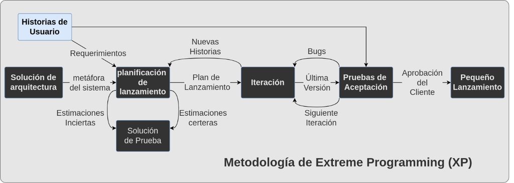

## **Introduciéndonos a la Agilidad o Agilismo**

Teniendo en cuenta lo dicho por Pressman y Maxim (2021), XP es una metodología de desarrollo ágil (pág. 46) por lo que a este punto, es preciso preguntarnos:

**¿Qué es una metodología Ágil? O ¿Qué es la Agilidad?**

## **La Agilidad**

Según, Pressman y Maxim (2021) “La ingeniería de software ágil combina una ﬁlosofía y un conjunto de lineamientos de desarrollo.” (pág. 37) Dicha filosofía “fomenta la satisfacción del cliente y la entrega incremental anticipada de software; equipos de proyecto pequeños y muy motivados; métodos informales; productos de trabajo de ingeniería de software mínimos y una simpleza de desarrollo en general” (pág. 37)

Además de lo anterior, según Pressman y Maxim (2021), la agilidad:

- Busca adaptarse positivamente al cambio
- “Fomenta estructuras y actitudes de equipo que faciliten la comunicación”
- Enfatiza el desarrollo rápido funcional
- Acepta a quien solicita el software como parte del equipo de trabajo
- Se apoya en el manifiesto Ágil.

## **Manifiesto por el Desarrollo Ágil de Software**

Estamos descubriendo formas mejores de desarrollar software tanto por nuestra propia experiencia como ayudando a terceros. A través de este trabajo hemos aprendido a valorar:

**Individuos e interacciones** sobre procesos y herramientas  
**Software funcionando** sobre documentación extensiva  
**Colaboración con el cliente** sobre negociación contractual  
**Respuesta ante el cambio** sobre seguir un plan

Esto es, aunque valoramos los elementos de la derecha, valoramos más los de la izquierda.

| Kent Beck Mike Beedle Arie van Bennekum Alistair Cockburn Ward Cunningham Martin Fowler | James Grenning Jim Highsmith Andrew Hunt Ron Jeffries Jon Kern Brian Marick | Robert C. Martin Steve Mellor Ken Schwaber Jeff Sutherland Dave Thomas |
| --- | --- | --- |

## **Algunas fallas de seguridad de XP**

Ahora teniendo más claro qué es XP, se tratará el aspecto de la seguridad en XP en donde se iniciará mencionando algunos defectos de seguridad del modelo.

### **Al igual que otras metodologías Agile, XP no incluye seguridad**

Segun Ghani y Yasin (2013) “las metodologías agiles tales como Scrum, FDD, DSDM y XP no sugieren o incluyen elementos de seguridad en sus modelos. En general, la exclusión de elementos de seguridad de los procesos de desarrollo ágiles crean software vulnerable” (pág. 215).

Lo anterior significa que XP de base no promueve actividades que permitan el desarrollo de software seguro.

### **Falta de documentación**

Segun Ghani y Yasin (2013) XP no prioriza la documentación de diseño y sus especificaciones de interfaz detalladas no son compatibles con el estándar de la ingeniería de seguridad (p. 218).

Teniendo en cuenta lo anterior, la implementación de algunas actividades de seguridad en XP podrían no ser compatibles o tener dificultades con el modelo debido a la falta o poca documentación que promueve el modelo en sí.

### **Problemas con el diseño y la arquitectura segura**

El problema de la falta de documentación mencionado anteriormente se relaciona con esta problemática debido a que el proceso de desarrollo de XP no incentiva la documentación intensiva mientras que los artefactos de seguridad como los casos de abuso, los arboles de ataque, patrones de ataque y el diseño de arquitectura segura son necesarios para la evaluación de seguridad (Ghani y Yasin, 2013, pág. 219).

## **Explicación de cómo se implementa seguridad en XP**

En Extreme Programming, como en otras metodologías o frameworks ágiles, la seguridad no tiene un lugar específico en su estructura. Sin embargo en el transcurso de los años XP y las demás metodologías ágiles ha desarrollado dos aproximaciones principales sobre cómo abordar este tema.

- **La corriente Implícita**
- **La corriente Explícita**

Estas corrientes buscan encontrar soluciones a la falta de enfoque en la seguridad por parte de las metodologías ágiles como scrum y XP. Es evidente que esta falta de foco ha ocasionado una falta de documentación disponible que oriente a los desarrolladores a solventar el problema de implementar política de seguridad en ciclo de desarrollo. Y por ende se han presentado críticas de que estas metodologías tienden a generar software inseguro.

> No es la metodología la que desarrolla software inseguro. son los grupos de desarrollo quienes lo hacen.

### **Recordemos los cuatro hitos principales en cada iteración en la implementación de una metodología ágil como XP.**

1. Identificación / Diseño
2. Implementación / Desarrollo
3. verificación / Pruebas
4. Revision / Aprobacion

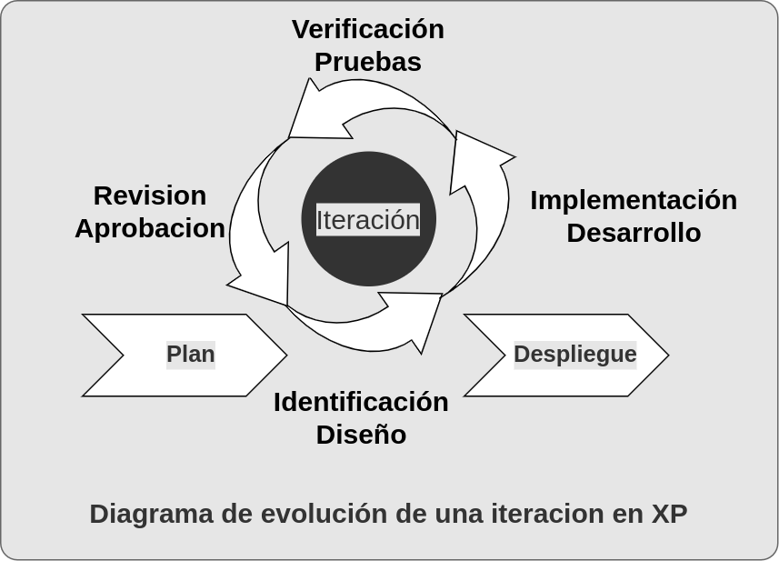

## **La corriente Implícita**

Esta corriente, que es la usada más comúnmente, integra las consideraciones para el desarrollo de software seguro en las listas de actividades de las interacciones como un objetivo más a cumplir, con la misma jerarquía que cualquier otra actividad, con el agravante que la seguridad en la mayoría de los casos no está dentro de la lista de requerimientos del cliente, la cual es un eje central en XP.

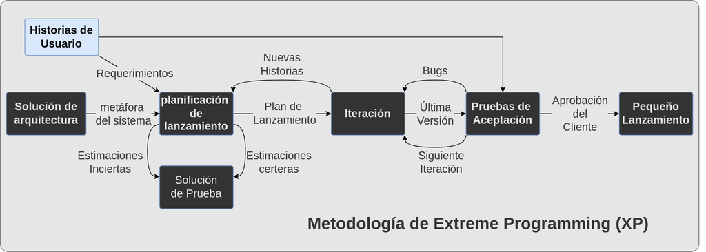

## **Ventajas de la aproximación implícita al desarrollo seguro.**

La principal ventaja de esta aproximación es su flexibilidad al aplicarlo solamente en las interacciones donde la gerencia del proyecto considera que es importante integrar procedimientos para asegurar la seguridad en el ciclo de desarrollo. No atrasa las iteraciones. Si los requerimientos del proyecto son de baja seguridad, esta solución es suficiente y no sobrecarga al equipo de desarrollo con trabajo innecesario.

## **Desventajas de la aproximación implícita al desarrollo seguro.**

Los mismos puntos que constituyen una ventaja en la aproximación implícita, es donde surgen sus principales problemas para la seguridad en el ciclo de desarrollo. Es fácil cometer errores cruciales en cuanto a seguridad, ya que el enfoque de las metodologías ágiles es la rapidez y eficiencia en encontrar soluciones que funcionen y cumplan con los requerimientos del proyecto. No es recomendable esta aproximación a soluciones que requieren niveles altos de seguridad, como pasarelas de pago, transacciones monetarias, de bienes o plataformas en las que se procese información sensible de empresas o usuarios, como datos médicos, o información clasificada.

## **La corriente Explícita**

A partir de los problemas que surgen de la adopción natural de manejar la seguridad en el ciclo de desarrollo de manera implícita la universidad Carnegie Mellon y su instituto para la investigación en software, propusieron la corriente explícita, mediante un paper titulado “Explicit Risk Management in Agile Processes”.

Para llegar a las conclusiones presentadas en este paper, se creó un proyecto llamado “The DaVinci Transform Project ” donde la universidad exploró durante cinco años, diferentes metodologías ágiles, en proyectos de diferentes tamaños, experiencia de los equipos. Al final de esta investigación se analizaron más de 5100 horas de trabajo de ingeniería, sus resultados y de allí generaron un framework que describe una metodología de trabajo para la integración de prácticas para el software seguro en las metodologías ágiles como XP.

El umbral de Éxito (Threshold of Success ,ToS) El primer paso para integrar mitigación del riesgo en metodologías ágiles.

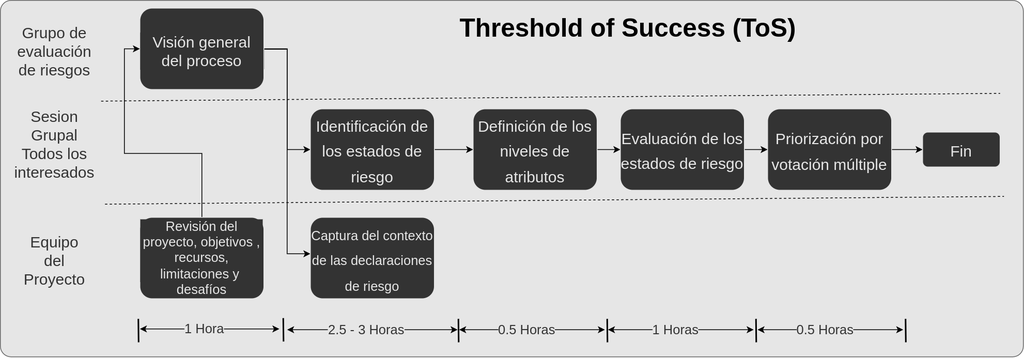

Al integrar un proceso de análisis del riesgo informático, Al principio de cada gran iteración, se consigue entender los retos de seguridad a los que se enfrenta cada iteración del proceso, asimismo esta actividad que consiste en tres reuniones separadas , dependiendo del enfoque cristaliza al final un documento accesible a todo el equipo. donde se encuentran los objetivos de seguridad para interacción así como las actividades concretas a realizar.

Adopción del ToS y diagrama de cómo se integra una política de seguridad explícita en la metodología XP

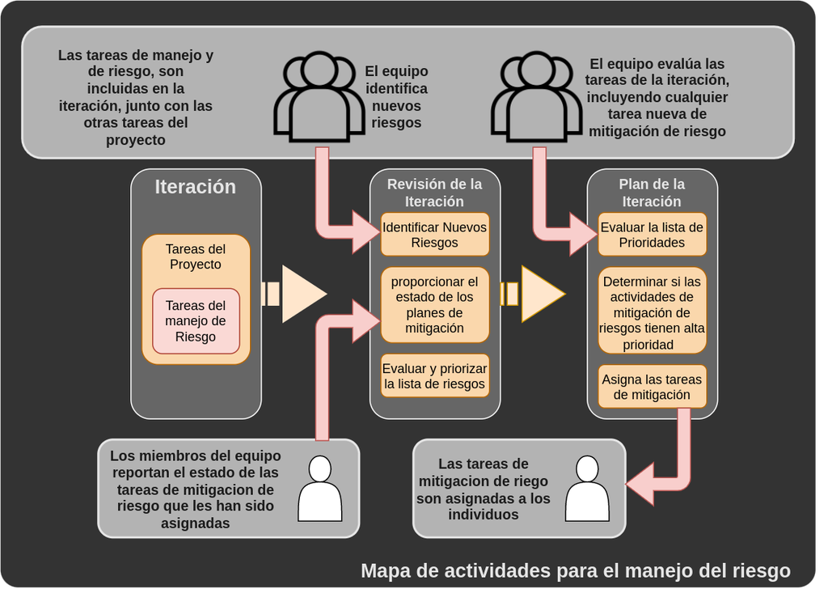

Este gráfico muestra cómo se suceden las actividades durante las interacciones del XP.

Luego de la primera reunión donde se establece el ToS, los resultados de este se ven reflejados como entradas en las tareas del manejo del riesgo y a partir de allí, el equipo de desarrollo, mientras avanza con el proyecto, detecta nuevos riesgos, los prioriza y actualiza las tareas de mitigación, los cuales sirven como input para el inicio de la siguiente iteración de la metodología.

Los resultados de aplicar esta aproximación al desarrollo de software seguro mostraron un importante cambio en la calidad del software desarrollado, mientras que por otro lado se invirtió más tiempo para alcanzar estos objetivos, lo que es normal pues al contrario de la aproximación implícita a la seguridad, la aproximación explícita mantiene en foco la seguridad y es natural que se produzca este gasto de tiempo extra en búsqueda de mayor calidad del software.

### **Conclusión 1**

La seguridad en el ciclo del desarrollo, nos permite a los responsables de crear productos informáticos, tener conciencia de la importancia de salvaguardar y proteger los datos de nuestros clientes.

Gracias a los modelos existentes en la seguridad en el ciclo del desarrollo, se nos hace mas factible entender las diferentes etapas que cubre cada uno de estos modelos, para así poder tener un buen planteamiento a la solución de la seguridad de nuestro producto.

### **Conclusión 2**

Los avances tecnológicos van demasiado rápido, día tras día hay nuevas herramientas y mejoras en el ámbito del desarrollo de software, con esto también se ve la necesidad, que nuevas metodologías emerjan, y así poder tener productos en menor tiempo con una gran calidad requerida.

Extreme Programming (XP), nos da ese respaldo de ir a la rapidez de lo que hoy vemos en el desarrollo de software. Es una metodología que tiene como objetivo, mejorar la calidad del software, también nos permite hacer entregas a corto plazo y que el cliente pueda, participar y hacer nuevos requerimientos y así adaptarse fácilmente.

Con esta metodología, vamos a encontramos una serie de principios, valores y prácticas, como estamos acostumbrados a las normas diaria de cualquier ciudadano que lo rige normativas de convivencia en la sociedad.

### **Conclusión 3**

Las metodologías como XP, nos resuelven muchas problemáticas a lo largo del desarrollo, ya que se enfoca en agilizar el proceso de entrega de producto, con un gran alto nivel de calidad. Pero esto no quiere decir que la seguridad en esta metodología, sea una prioridad, Pero existen algunos métodos o corrientes los cuales se puede aplicar, y no afectar el proceso de implementación de la metodología.

Se habla de corriente implícita, que lo que nos indica es que, en la lista del desarrollo, especifiquemos una serie de actividades a tener en cuenta e implementar la seguridad dentro lo pactado a desarrollar. También cabe lugar el termino de corriente explicita, que básicamente trata de una modelo, que integra por cada iteración actividades que analiza los riesgos y luego de reunirse con el equipo llegar a un consenso, para encontrar los objetivos de seguridad, para dichas iteraciones.

De esta manera encontramos que, las metodologías modernas como, las agiles y XP, aunque la prioridad no es muy necesariamente la seguridad, siempre hay un modo para poder aplicar un proceso que se pueda adaptar, a estos modelos y no quedar con una y gran importante deuda técnica, como lo es la **seguridad en el ciclo del desarrollo del software.**

### Referencias

AltexSoft. (Enero 18 de 2021). Extreme Programming: Values, Principles, and Practices. https://www.altexsoft.com/blog/business/extreme-programming-values-principles-and-practices/

Cunningham, W. (2001). Manifesto for Agile Software Development. https://agilemanifesto.org/iso/en/manifesto.html

Digité. (s.f.). Introduction to Extreme Programming (XP). Extreme Programming (XP) Methodology. https://www.digite.com/wp-content/uploads/2021/06/extreme-programming-overview.png

Erlijman, A. y Goyén, A. (2001). PROBLEMAS Y SOLUCIONES EN LA IMPLEMENTACIÓN DE EXTREME PROGRAMMING [Memoria de Grado, UNIVERSIDAD CATÓLICA DEL URUGUAY DÁMASO ANTONIO LARRAÑAGA]. https://alejandrogoyen.com/MemoriaDeGradoXP.pdf

Ghani, I., y Yasin, I. (2013). Software Security Engineering in Extreme Programming Methodology: A Systematic Literature Review. Science International, 25(2). https://citeseerx.ist.psu.edu/document?repid=rep1&type=pdf&doi=fb3ac381f336911fe46c638abdde53376d74a5e5

Hubner, J. P., Sotomayor, K. P., & Miguel, P. V. L. (2021). Modelo de Desarrollo de Software de la Programación Extrema sobre Scrum para Gestión de Software Ágil. Revista Ibérica de Sistemas e Tecnologias de Informação, (E39), 611-626. https://www.researchgate.net/profile/Hubner-Janampa/publication/349704822_Software_Development_Model_of_the_Extreme_Programming_on_Scrum_for_Agile_Software_Management/links/603daf88a6fdcc9c78081b60/Software-Development-Model-of-the-Extreme-Programming-on-Scrum-for-Agile-Software-Management.pdf

Pressman, R. S., Maxim, B. R.(2021). Ingeniería de software. McGraw-Hill Interamericana. https://www-ebooks7-24-com.loginbiblio.poligran.edu.co/?il=16414

Toro, R. (2021, March 11). ¿Qué es la seguridad de la información y cuantos tipos hay? PMG SSI - ISO 27001. https://www.pmg-ssi.com/2021/03/que-es-la-seguridad-de-la-informacion-y-cuantos-tipos-hay/

Unidad 1 / Escenario 1 - Lectura fundamental- Conceptos básicos de seguridad de la información Conceptos básicos sobre seguridad informática. (2019, September 11). Informatizarte. http://informatizarte.com.ar/conceptos-basicos-sobre-seguridad-informatica/

Conceptos básicos de ciberseguridad que debes conocer. (n.d.). Osi.es. Retrieved December 4, 2022, from https://www.osi.es/es/actualidad/blog/2021/06/28/conceptos-basicos-de-ciberseguridad-que-debes-conocer

Nelson, C. R., Taran, G., & de Lascurain Hinojosa, L. (2008). Explicit Risk Management in Agile Processes. Agile Processes in Software Engineering and Extreme Programming, 190–201. doi:10.1007/978-3-540-68255-4_20

Musa, S. B., Norwawi, N. M., Selamat, M. H., & Sharif, K. Y. (2011). Improved extreme programming methodology with inbuilt security. 2011 IEEE Symposium on Computers & Informatics. doi:10.1109/isci.2011.595

https://www.iebschool.com/blog/que-es-el-xp-programming-agile-scrum/#:~:text=El%20Extreme%20Programming%20tiene%20como,en%20proyectos%20a%20corto%20plazo.

https://openwebinars.net/blog/extreme-programming-que-es-y-como-aplicarlo/